# Question 1

## Introduction

Like any other python project, we begin by importing some important libraries and modules:

```python
import pandas as pd
import matplotlib
import matplotlib.pyplot as plt
```

We begin by reading the data:

```python
d1 = pd.read_csv("2019-Winter-Data-Science-Intern-Challenge-Data-Set-Sheet1.csv")
d1.head(2)
```

|  | order_id | shop_id | user_id | order_amount | total_items | payment_method | created_at |
| --- | --- | --- | --- | --- | --- | --- | --- |
| 0 | 1 | 53 | 746 | 224 | 2 | cash | 2017-03-13 12:36:56 |
| 1 | 2 | 92 | 925 | 90 | 1 | cash | 2017-03-03 17:38:52 |

## Exploratory Data Analysis:

It is a good practice to conducta basic exploratory analysis to get a better sense of data.

```python
d1.size # there are 35000 data entries
```

```
35000
```

```python
d1.describe()# gives general statistics such as count, mean, standard devaiation, minimum, maximum value etc.
```

|  | order_id | shop_id | user_id | order_amount | total_items |
| --- | --- | --- | --- | --- | --- |
| count | 5000.000000 | 5000.000000 | 5000.000000 | 5000.000000 | 5000.00000 |
| mean | 2500.500000 | 50.078800 | 849.092400 | 3145.128000 | 8.78720 |
| std | 1443.520003 | 29.006118 | 87.798982 | 41282.539349 | 116.32032 |
| min | 1.000000 | 1.000000 | 607.000000 | 90.000000 | 1.00000 |
| 25% | 1250.750000 | 24.000000 | 775.000000 | 163.000000 | 1.00000 |
| 50% | 2500.500000 | 50.000000 | 849.000000 | 284.000000 | 2.00000 |
| 75% | 3750.250000 | 75.000000 | 925.000000 | 390.000000 | 3.00000 |
| max | 5000.000000 | 100.000000 | 999.000000 | 704000.000000 | 2000.00000 |

order_amount seems to have the an unusually high standard deviation. the range is wide from 90 units to 704000 units. We could use this information later.

```python
d1.count()
```

```
order_id          5000
shop_id           5000
user_id           5000
order_amount      5000
total_items       5000
payment_method    5000
created_at        5000
dtype: int64
```

```python
d1.isna().sum() # No null Values.
```

```
order_id          0
shop_id           0
user_id           0
order_amount      0
total_items       0
payment_method    0
created_at        0
dtype: int64
```

```python
len(d1) # 5000 rows
```

```
5000
```

```python
d1.mean() # all the means
```

```
order_id        2500.5000
shop_id           50.0788
user_id          849.0924
order_amount    3145.1280
total_items        8.7872
dtype: float64
```

Notice the average or order_amount. it is 3145.1280. The average of order_amount was considered as AOV (average order value). This is not considered an accurate calculator of AOV.

A more accurate approach for AOV = sum of order_amount / sum of order_amount

There are a couple of approaches that can be considered.

- 1 - We could calculate the total order_amount and divide it by the sum of total_items.
- 2 - We could also calculate the individual averages( create a new column avg_aovs = order_amount/total_amount) and then futher take the average of this new column. When we say 'averages' we could do 2 things: --- 2a - mean of the avg_aovs --- 2b - median of the avg_aovs

## Analysis and Observation

```python
AOV_1 = d1['order_amount'].sum() / d1['total_items'].sum()
AOV_1
```

```
357.92152221412965
```

this is without tkaing outliers into consideration. Let us look for outliers in the order_amount and total_items features.

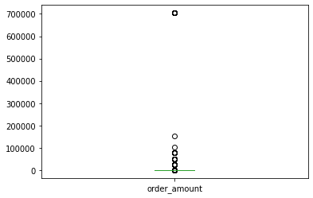

```python
# boxplots for order_amount and total_items
d1['order_amount'].plot(kind = 'box')
```

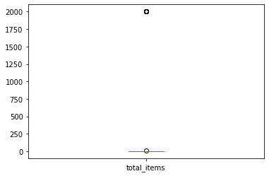

```python
d1['total_items'].plot(kind = 'box')
```

The boxplots suggests presence of outliers. Its not a great practice to simply remove outliers as they can potentially showcase interesting insights of the situation. It is a good practice to always first investigate the outliers and then make a more informed decision as to how to preceed further. For the sake of this project, since we have limited information, let us attempt to remove the outliers and see.

We define a function 'outliers' which we will use to create a list of indcies that contain outliers for the respective feature. We are developing a function since we might need to perform this a number of times. this function will return a list of indicies that contain the outlier for respective feature.

In addition we develop another function, 'remove'. this function, will take returned list from 'outliers' function and return a clean dataframe without the outliers.

```python
def outliers(df, ft):
    Q1 = df[ft].quantile(0.25)    # defining the 1st quantile
    Q3 = df[ft].quantile(0.75)    # defining the 3rd quantile
    IQR = Q3 - Q1
    lower_bound = Q1 - 1.5 * IQR  # 1.5 + 1.5 = 3 standard deviation
    upper_bound = Q3 + 1.5 * IQR

    # getting the indexes             #  OR operater
    ls = df.index[(df[ft] < lower_bound) | (df[ft] > upper_bound)]
    # anything lower than the lower bound OR anything greater than the upper bound

    return ls # list

def remove(df, ls):      # ls -> index list
    ls = sorted(set(ls)) # to get unique indices in ascending order.
    df2 = df.drop(ls)    # drop the respective indicies, df2 is the clean dataframe.
    return df2
```

```python
ind_ls_1 = []
for i in ['order_amount','total_items']:
    ind_ls_1.extend(outliers(d1, i))
ind_ls_1 # these are the indices of the outliers
d1_clean = remove(d1, ind_ls_1)
d1_clean
```

|  | order_id | shop_id | user_id | order_amount | total_items | payment_method | created_at |
| --- | --- | --- | --- | --- | --- | --- | --- |
| 0 | 1 | 53 | 746 | 224 | 2 | cash | 2017-03-13 12:36:56 |
| 1 | 2 | 92 | 925 | 90 | 1 | cash | 2017-03-03 17:38:52 |
| 2 | 3 | 44 | 861 | 144 | 1 | cash | 2017-03-14 4:23:56 |
| 3 | 4 | 18 | 935 | 156 | 1 | credit_card | 2017-03-26 12:43:37 |
| 4 | 5 | 18 | 883 | 156 | 1 | credit_card | 2017-03-01 4:35:11 |
| ... | ... | ... | ... | ... | ... | ... | ... |
| 4995 | 4996 | 73 | 993 | 330 | 2 | debit | 2017-03-30 13:47:17 |
| 4996 | 4997 | 48 | 789 | 234 | 2 | cash | 2017-03-16 20:36:16 |
| 4997 | 4998 | 56 | 867 | 351 | 3 | cash | 2017-03-19 5:42:42 |
| 4998 | 4999 | 60 | 825 | 354 | 2 | credit_card | 2017-03-16 14:51:18 |
| 4999 | 5000 | 44 | 734 | 288 | 2 | debit | 2017-03-18 15:48:18 |

4859 rows × 7 columns

```python
aov2 = d1_clean['order_amount'].sum() / d1_clean['total_items'].sum()
aov2
```

```
150.60816800337696
```

```python
aov3 = d1_clean['order_amount'].mean() / d1_clean['total_items'].mean()
aov3
```

```
150.60816800337696
```

```python
# aov4 = d1_clean['order_amount'].mode() / d1_clean['total_items'].mode()
# aov4
```

[output not shown]

Another approach is to calcualate respective averages and then calculate the average of the average order value. for this we need to create a new column which is the ratio of order_amount and total_items. We will name the new column 'avg'.

it is generally prefered that the original imported datafame should not be manipulated. Since we are attempting to create a new column avg_aovs, let us first create a copy of the original dataframe and work on that one.

```python
d2 = d1.copy()
d2.head(2)
```

|  | order_id | shop_id | user_id | order_amount | total_items | payment_method | created_at |
| --- | --- | --- | --- | --- | --- | --- | --- |
| 0 | 1 | 53 | 746 | 224 | 2 | cash | 2017-03-13 12:36:56 |
| 1 | 2 | 92 | 925 | 90 | 1 | cash | 2017-03-03 17:38:52 |

```python
d2['avg'] = d2['order_amount'] / d2['total_items']
d2.head(2)
```

|  | order_id | shop_id | user_id | order_amount | total_items | payment_method | created_at | avg |
| --- | --- | --- | --- | --- | --- | --- | --- | --- |
| 0 | 1 | 53 | 746 | 224 | 2 | cash | 2017-03-13 12:36:56 | 112.0 |
| 1 | 2 | 92 | 925 | 90 | 1 | cash | 2017-03-03 17:38:52 | 90.0 |

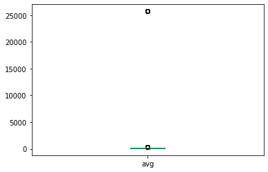

```python
# let us look for outliers of avg column. and attempt to remove them
d2['avg'].plot(kind = 'box')
```

```python
# removing outliers:
ind_l2_2 = []
ind_ls_2.extend(outliers(d2, 'avg'))
ind_ls_2 # these are the indices of the outliers
d2_clean = remove(d2, ind_ls_2)
d2_clean
```

[output not shown]

4903 rows × 8 columns

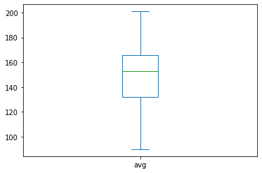

```python
d2_clean['avg'].plot(kind = 'box')
```

```python
aov5 = d2_clean['avg'].mean()
aov5
```

```
150.40016316540894
```

```python
aov6 = d2_clean['avg'].median()
aov6
```

```
153.0
```

```python
# aov7 = d2_clean['avg'].mode()
# aov7
```

[output not shown]

## Conclusion:

We are only considering mean and median since the feature is quantitative. Had the feature been qualitative, we would have considered mode.

Based on our analysis, $150 dollar seem to be a more accurate Average of value for the given situation.

# Question 2

### Part A: How many orders were shipped by speedy express in total?

Orders table contain details of orders. This is our main table. We need to count all the orders shipped by ‘Speedy Express’. The table consists of ShipperID. We need to identify which Shipper ID represents Speedy Express. That detail is in the ‘Shipper’ table. We join the From ‘Shippers’ table, we get that ShipperID = 1 is for Speedy Express.

```python
'''
SELECT ShipperName , COUNT(*)
    FROM [Orders]
    JOIN Shippers ON Orders.ShipperID = Shippers.ShipperID
    WHERE ShipperName = 'Speedy Express';
'''
```

```
"\nSELECT ShipperName , COUNT(*)\n    FROM [Orders]\n    JOIN Shippers ON Orders.ShipperID = Shippers.ShipperID\n    WHERE ShipperName = 'Speedy Express';\n"
```

ANSWER: Speedy Express shipped a total of **54 orders**.

### Part B: What is the last name of the employee with the most orders?

This time we need to extract the last name of the employee. This information is available in ‘Employees’ table. The table also contains the ‘EmployeeID’ of the respective employee. We will match (join) it with the EmployeeID from ‘Orders’ table.

```python
'''
SELECT LastName, COUNT(LastName)
    FROM [Orders]
    JOIN Employees ON Orders.EmployeeID = Employees.EmployeeID
    GROUP BY LastName
    ORDER BY COUNT(LastName) DESC
    LIMIT 1

'''
```

```
'\nSELECT LastName, COUNT(LastName)\n    FROM [Orders]\n    JOIN Employees ON Orders.EmployeeID = Employees.EmployeeID\n    GROUP BY LastName\n    ORDER BY COUNT(LastName) DESC\n    LIMIT 1\n    \n'
```

ANSWER: The last name of the employee with the most orders is **‘Peacock’**

### Part C: What product was ordered the most by customers in Germany?

For this questions, we need to merge a number of tables since different tables contain different interconnected information. In total, we used Orders, OrderDetails, Products and Customers tables. We selected only Germany. Since we needs, maximum orders per country, we will group the ProductNames and add the quantity. To get the maximum Orders, we will sort the sum in descending order and extract only the 1st row.

```python
'''
SELECT ProductName, SUM(Quantity)
    FROM [Orders]
    JOIN OrderDetails ON Orders.OrderID = OrderDetails.OrderID
    JOIN Products ON Products.ProductID = OrderDetails.ProductID
    JOIN Customers ON Orders.CustomerID = Customers.CustomerID
    WHERE Country = 'Germany'
    GROUP BY ProductName
    ORDER BY SUM(Quantity) DESC
    LIMIT 1
'''
```

[output not shown]

ANSWER: **Boston Crab Meat** was ordered the most by customers in Germany with a grand total of 160 orders.